# Tutorial

### Average cohort effect

**fect** allows us to estimate and visualize the ATTs for sub-groups of treated units. For example, it can draw the gap plot for units that adopt the treatment at the same time under staggered adoption, which is defined as “Cohort” in Sun and Abraham (2021). Our simulated dataset is not ideal to demonstrate this functionality because the treatment switches on and off. To improve feasibility, we define a cohort as a group of treated units that first adopt the treatment at the same time.

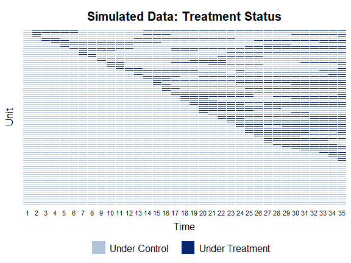

```r
panelview(Y ~ D, data = simdata, index = c("id","time"), by.timing = TRUE,
  axis.lab = "time", xlab = "Time", ylab = "Unit",
  background = "white", main = "Simulated Data: Treatment Status")
```

The function **get.cohort()** shipped in the package **paneltools** can generate a new variable “Cohort” based on the timing when treated units first get treated.

```r
library(paneltools)
simdata.cohort <- get.cohort(data = simdata,D = 'D',index = c("id","time"))
print(table(simdata.cohort[,'Cohort']))
```

```
#>
#>  Cohort:1 Cohort:10 Cohort:11 Cohort:12 Cohort:13 Cohort:14 Cohort:15 Cohort:16
#>        35       245       105        35       175       175       210       245
#> Cohort:17 Cohort:18 Cohort:19  Cohort:2 Cohort:20 Cohort:21 Cohort:22 Cohort:23
#>       210       210       140       280       315       105       140       210
#> Cohort:24 Cohort:25 Cohort:26 Cohort:27 Cohort:28 Cohort:29  Cohort:3 Cohort:30
#>       105       280       175       210        70       105       175        35
#> Cohort:31 Cohort:33 Cohort:34 Cohort:35  Cohort:4  Cohort:5  Cohort:6  Cohort:7
#>       105        70       175       140        70       140       105       210
#>  Cohort:8  Cohort:9   Control
#>       105       140      1750
```

We can also pass a list of **intervals** for first get-treated time into the `entry.time` option of **get.cohort()**. For example, we can categorize all treated units into the group that adopts the treatment between time 21 and 27, and the group that adopts the treatment in time 30 and 33.

```r
simdata.cohort2 <- get.cohort(data = simdata,D = 'D',index = c("id","time"),
                               entry.time = list(c(21,27),c(30,33)))
print(table(simdata.cohort2[,'Cohort']))
```

```
#>
#> Cohort:21-27 Cohort:30-33 Cohort:Other      Control
#>         1225          210         3815         1750
```

By setting the option `group = "Cohort"`, **fect** estimates the ATT for each specified sub-group and saves it for further visualization.

```r
out.ife.g <- fect(Y ~ D + X1 + X2, data = simdata.cohort, index = c("id","time"),
          force = "two-way", method = "ife", CV = TRUE, r = c(0, 5),
          se = TRUE, nboots = 200, parallel = TRUE, group = 'Cohort')
out.ife.g.p <- fect(Y ~ D + X1 + X2, data = simdata.cohort, index = c("id","time"),
          force = "two-way", method = "ife", CV = FALSE,
          placeboTest = TRUE, placebo.period = c(-2,0),
          se = TRUE, nboots = 200, parallel = TRUE, group = 'Cohort')
```

Then one can draw the gap plot, as well as the equivalence plot, for each sub-group. Here we present the gap plot for Cohort 22.

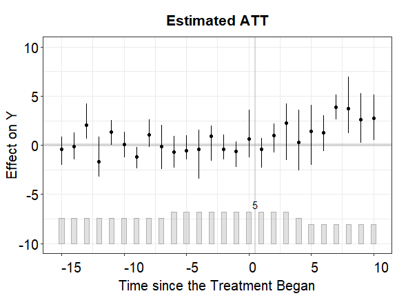

```r
plot(out.ife.g, show.group = "Cohort:22",
          xlim = c(-15, 10), ylim = c(-10, 10))
```

### Other estimators

The logic of imputation estimator can be extended to more settings.

**Complex Fixed Effects.** When there exists more dimensions of fixed effects in addition to the unit and time fixed effects, we can resort to the **“cfe”**(complex fixed effects) estimator to impute the counterfactual based on a linear model with multiple levels of fixed effects. It accepts two options: `sfe` specifies simple (additive) fixed effects in addition to the unit and time fixed effects and `cfe` receives a *list* object and each component in the list is a vector of length 2. The value of the first element of each component is the name of *group* variable for which fixed effects are to be estimated (e.g. unit names); the value of the second element is the name of a regressor (e.g., a time trend). For example, we can estimate a model with an additional fixed effects **FE3** along with a unit-specific time trend.

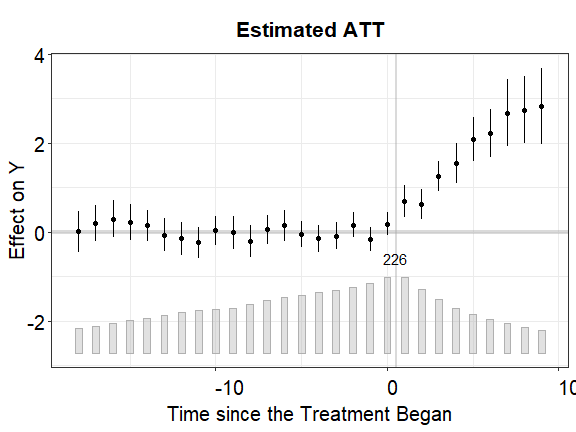

```r
simdata[,"FE3"] <- sample(c(1,2,3,4,5), size = dim(simdata)[1], replace = TRUE)
out.cfe <- fect(Y ~ D + X1 + X2, data = simdata, index = c("id","time"),
  method = "cfe", force = "two-way", se = TRUE, parallel = TRUE, nboots = 200,
  sfe = c("FE3"), cfe = list(c("id","time")))
plot(out.cfe)
```

**Polynomial.** When only need to include unit-specific time trends, we can use the **“polynomial”** estimator. By setting `degree = 2`, we can estimate the ATT based on a linear model with unit and time fixed effects, along with a unit-specific time trend and quadratic time trend.

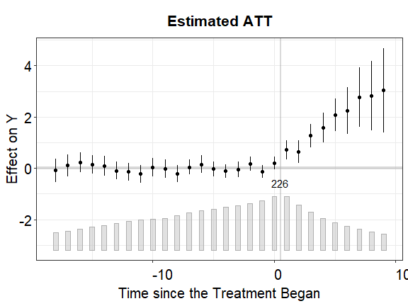

```r
out.poly <- fect(Y ~ D + X1 + X2, data = simdata, index = c("id","time"),
  method = "polynomial", force = "two-way", se = TRUE, parallel = TRUE, nboots = 200,
  degree = 2)
plot(out.poly)
```

## Additional Notes

1. By default, the program will drop the units that have no larger than 5 observations under control, which is the reason why sometimes there are less available units in the placebo test or carryover test than in the original estimation. We can specify a preferred criteria in the option `min.T0` (default to 5). As a rule of thumb for the IFE estimator, the minimum number of observations under control for a unit should be larger than the specified number of factor `r`.
2. We can get replicable results by setting the option `seed` to a certain integer, no matter whether the parallel computing is used.
3. When `na.rm = FALSE` (default), the program allows observations to have missing outcomes $Y$ or covariates $X$ but decided treatment statuses $D$. Otherwise the program will drop all observations that have missing values in outcomes, treatments, or covariates.

# Reference

Athey, Susan, Mohsen Bayati, Nikolay Doudchenko, Guido Imbens, and Khashayar Khosravi. 2021. “Matrix Completion Methods for Causal Panel Data Models.” *Journal of the American Statistical Association* forthcoming.

Borusyak, Kirill, Xavier Jaravel, and Jann Spiess. 2021. “Revisiting Event Study Designs: Robust and Efficient Estimation,” August. https://arxiv.org/abs/2108.12419.

Gardner, John. 2021. “Two-Stage Differences in Differences.” Working Paper, Boston College. https://bit.ly/3AF32Af.

Gobillon, Laurent, and Thierry Magnac. 2016. “Regional Policy Evaluation: Interactive Fixed Effects and Synthetic Controls.” *Review of Economics and Statistics* 98 (3): 535–51.

Liu, Licheng, Ye Wang, and Yiqing Xu. 2022. “A Practical Guide to Counterfactual Estimators for Causal Inference with Time-Series Cross-Sectional Data.” *American Journal of Political Science* conditionally accepted.

Sun, Liyang, and Sarah Abraham. 2021. “Estimating Dynamic Treatment Effects in Event Studies with Heterogeneous Treatment Effects.” *Journal of Econometrics* 225 (2): 175–99.

Xu, Yiqing. 2017. “Generalized Synthetic Control Method: Causal Inference with Interactive Fixed Effects Models.” *Political Analysis* 25 (1): 57–76.